# Week 03 - In Class Excersize

Uğur Aşkar

2020-11-04

## Preparing data for analysis

```r
raw_df = read_xlsx("C:\\data\\EVDS_istanbul_property_data\\EVDS_istanbul_property_data.xlsx")
print(raw_df,n=5)
```

```
## # A tibble: 187 x 9
##   Tarih `TP AKONUTSAT1 ~ `TP AKONUTSAT2 ~ `TP AKONUTSAT3 ~ `TP AKONUTSAT4 ~
##   <chr> <chr>            <chr>                       <dbl>            <dbl>
## 1 2010~ <NA>             <NA>                           NA               NA
## 2 2010~ <NA>             <NA>                           NA               NA
## 3 2010~ <NA>             <NA>                           NA               NA
## 4 2010~ <NA>             <NA>                           NA               NA
## 5 2010~ <NA>             <NA>                           NA               NA
## # ... with 182 more rows, and 4 more variables: `TP DISKONSAT ISTANBUL` <dbl>,
## #   `TP HEDONIKYKFE IST` <dbl>, `TP HKFE02` <dbl>, `TP TCBF02 ISTANBUL` <dbl>
```

Pulling data from our file system with read_xlsx function.

```r
row_id_df = raw_df %>% transmute(id = row_number(), raw_df)
description_row_id = row_id_df %>% filter(is.na(Tarih)) %>% summarise(description_row_id = min(id))
minimum_description_row_id = description_row_id$description_row_id[1]
clean_df = row_id_df %>%
  filter(id < minimum_description_row_id) %>%
  drop_na() %>%
  filter(id < minimum_description_row_id) %>%
  dplyr::rename_all(funs(make.names(.))) %>%
  transmute(TARIH = as.yearmon(Tarih), TOPLAM_SATIS = as.numeric(TP.AKONUTSAT1.T40), IPOTEK_SATIS = as.numeric(TP.AKONUTSAT1.T40), ILK_EL_SATIS = TP.AKONUTSAT3.T40, IKINCI_EL_SATIS = TP.AKONUTSAT4.T40, YABANCI_SATIS = TP.DISKONSAT.ISTANBUL, YENI_KONUT_FIYAT_ENDEKS = TP.HEDONIKYKFE.IST, TR10 = TP.HKFE02, KONUT_BIRIM_FIYAT = TP.TCBF02.ISTANBUL)
print(clean_df,n=5)
```

```
## # A tibble: 92 x 9
##   TARIH TOPLAM_SATIS IPOTEK_SATIS ILK_EL_SATIS IKINCI_EL_SATIS YABANCI_SATIS
##   <yea>        <dbl>        <dbl>        <dbl>           <dbl>         <dbl>
## 1 Oca ~        18235        18235         8298            9937           138
## 2 Şub ~        18971        18971         8277           10694           120
## 3 Mar ~        21570        21570         9542           12028           198
## 4 Nis ~        20791        20791         8751           12040           209
## 5 May ~        22030        22030         9371           12659           188
## # ... with 87 more rows, and 3 more variables: YENI_KONUT_FIYAT_ENDEKS <dbl>,
## #   TR10 <dbl>, KONUT_BIRIM_FIYAT <dbl>
```

- Adding row numbers to clean data which we will be using it to ignore descriptions from excel, I preferred this method compared to n_max because If I added a limit where the descriptions were manually we could ignore new values. This one will find where descriptions are automatically.
- Adding proper column names for readability and dropping rows which contains null values.
- Converting data types as well because we can’t divide string values.

```r
analytical_df = clean_df %>%
  transmute(TARIH, ILK_EL_SATIS, ILK_EL_ORAN = ((ILK_EL_SATIS / TOPLAM_SATIS)*100), IKINCI_EL_SATIS, IKINCI_EL_ORAN = ((IKINCI_EL_SATIS / TOPLAM_SATIS)*100), YABANCI_SATIS, YABANCI_SATIS_ORAN = ((YABANCI_SATIS / TOPLAM_SATIS)*100), TC_SATIS = TOPLAM_SATIS - YABANCI_SATIS, TC_SATIS_ORAN = ((TOPLAM_SATIS - YABANCI_SATIS)/TOPLAM_SATIS)*100)
print(analytical_df,n=5)
```

```
## # A tibble: 92 x 9
##   TARIH ILK_EL_SATIS ILK_EL_ORAN IKINCI_EL_SATIS IKINCI_EL_ORAN YABANCI_SATIS
##   <yea>        <dbl>       <dbl>           <dbl>          <dbl>         <dbl>
## 1 Oca ~         8298        45.5            9937           54.5           138
## 2 Şub ~         8277        43.6           10694           56.4           120
## 3 Mar ~         9542        44.2           12028           55.8           198
## 4 Nis ~         8751        42.1           12040           57.9           209
## 5 May ~         9371        42.5           12659           57.5           188
## # ... with 87 more rows, and 3 more variables: YABANCI_SATIS_ORAN <dbl>,
## #   TC_SATIS <dbl>, TC_SATIS_ORAN <dbl>
```

Calculating percentage and adding new columns for analysis.

## Visualizing the data

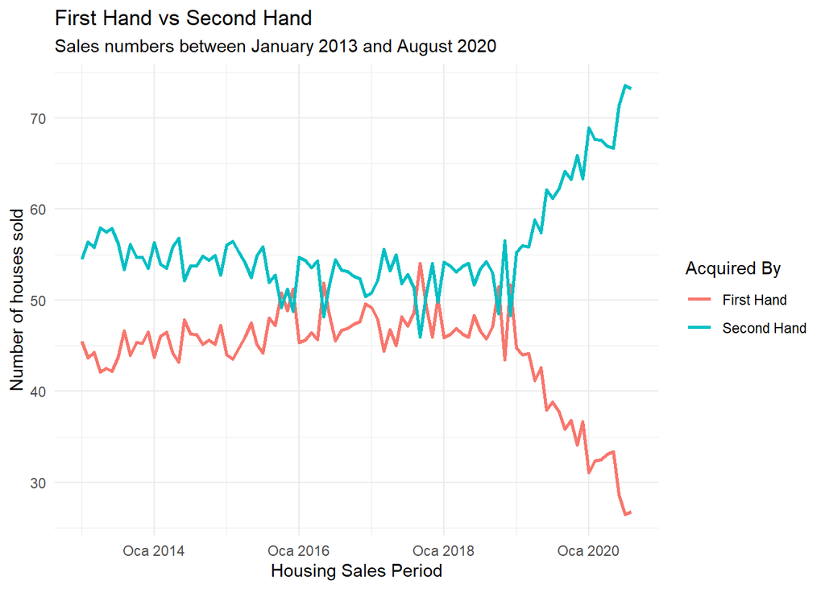

```r
ggplot(analytical_df, aes(x=as.yearmon(TARIH), group=1)) +
  geom_line(aes(y = ILK_EL_ORAN, color = "First Hand") , size = 1) +
  geom_line(aes(y = IKINCI_EL_ORAN, color = "Second Hand"), size = 1) +
  theme_minimal() +
  labs(x = 'Housing Sales Period', y = 'Number of houses sold', color = "Acquired By", title = "First Hand vs Second Hand", subtitle = "Sales numbers between January 2013 and August 2020")
```

Here we can see that around late 2018 and early 2019 second hand market increased significantly, this might be due to decreased purchasing power compared to pre-2019. Since second hand houses are cheaper than first hand houses.

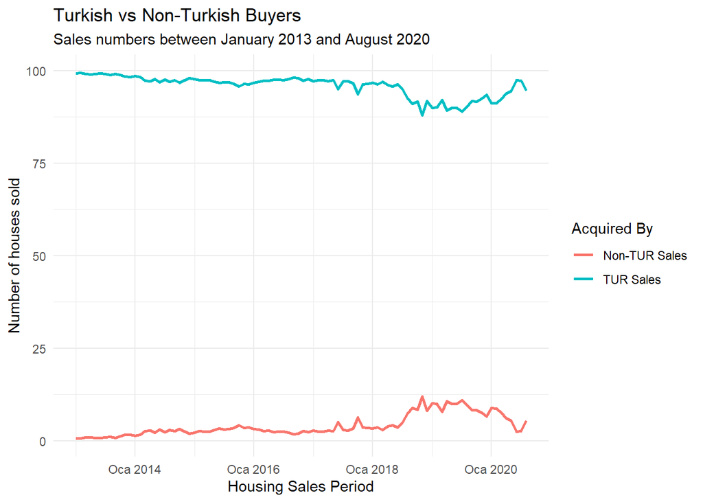

```r
ggplot(analytical_df, aes(x=as.yearmon(TARIH), group=1)) +
  geom_line(aes(y = YABANCI_SATIS_ORAN, color = "Non-TUR Sales") , size = 1) +
  geom_line(aes(y = TC_SATIS_ORAN, color = "TUR Sales"), size = 1) +
  theme_minimal() +
  labs(x = 'Housing Sales Period', y = 'Number of houses sold', color = "Acquired By", title = "Turkish vs Non-Turkish Buyers", subtitle = "Sales numbers between January 2013 and August 2020")
```

While this graph doesn’t show huge analysis opportunity it supports our first estimate, since purchasing power is going down in the same dates we can see that Non-Turkish buyers are significantly increased.

## Conclusion

We can see that since late-2018’s there is an economic crisis going on in Turkey. This pushes people to buy second-hand properties. This also encourages foreigners to spend money here because it’s cheaper.

## Sources

- https://www.datanovia.com/en/blog/how-to-create-a-ggplot-with-multiple-lines/
- https://stackoverflow.com/questions/27082601/ggplot2-line-chart-gives-geom-path-each-group-consist-of-only-one-observation
- https://stackoverflow.com/questions/6242955/converting-year-and-month-yyyy-mm-format-to-a-date
- https://www.datanovia.com/en/blog/ggplot-colors-best-tricks-you-will-love/
- https://github.com/yihui/rmarkdown-cookbook/issues/12

Analytical Sources:

- https://www.neoldu.com/konut-satis-2019-tuik-istatistik-rapor-rakam-38482h.htm
- https://tr.wikipedia.org/wiki/2018-20_T%C3%BCrkiye_d%C3%B6viz_ve_bor%C3%A7_krizi